# Introduction

PHRM3302 Tutorial

### Learning objectives for the week

1. Identify the impact of social factors to health
2. Understand the aim, methods and contributions of the social sciences
3. Apply key concepts from sociology and the social sciences to challenges in health

### Extend activities

- Social pharmacy
- Social determinants of disease
- Pharmacists and emergency contraception 1 and 2 (ET)
- Positivism v constructivism (ET)

### Social or biological determinants of disease?

> Consider the following disease or condition. Each statement asks you to evaluate whether incidence and success of treatment of the disease or condition is determined by “biological” factors, such as pathophysiology or genetics, or by “social” factors, such as where and how you live, your health beliefs and access and engagement with health services.

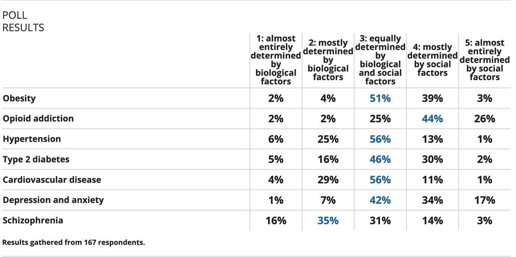

## Activity: Changed behaviour in dementia

### Case Scenario:

Mrs Johnson is an 82-year-old woman with a diagnosis of dementia. She moved into residential aged care 4 months ago. Over the past few weeks, the care staff noticed a change in her behaviour.

She has been experiencing severe agitation, frequent episodes of aggression, and hallucinations. She often screams at night, accusing imaginary intruders of trying to harm her. These symptoms have been causing significant distress for her and her family.

See GP and nurse approaches on the worksheet

1. Discuss the GP and nurse approaches in terms of the biomedical model and biopsychosocial model.
2. Analyse how agency, structure and power play out in this scenario (individual-level).

From the Royal Commission into Aged Care Quality and Safety, Interim Report (Tracey and Briggs 2019, 1)

> The system lacks transparency in communication, reporting and accountability. It is not built around the people it is supposed to help and support, but around funding mechanisms, processes and procedures. This, too, must change.

> Social definition metatheories take a constructionist perspective that assumes that individuals actively interpret the world and construct joint meanings about reality, typically using qualitative methods like in-depth interviews and participant observation.

> Social facts metatheories take a structurist perspective that assumes social structures are the primary forces shaping the social world and establish the facts of social life, typically using quantitative methods like surveys or analysis of existing records.

## Activity: Phronetic social science

Unpack the following quote from Staines, Hoffstaedter, and Binnie (2023), Chapter 1:

> Schram (2012: 18-19) presents four justifications for phronetic social science as follows:

> 1. “Given the dynamic nature of human interaction in the social world, social inquiry is best practiced when it does not seek general laws of action that can be used to predict courses of action, but instead offer a critical assessment of values, norms and structures of power and dominance. Social inquiry is better when it is linked to questions of the good life, that is, to questions of what we ought to do.

> 2. While the social world is dynamic, social research is best seen as dialogical. Social inquiry is not a species of theoretical reason but of practical reason. Practical reason stays within a horizon of involvements in social life. For Flyvbjerg, this entails a context-dependent view of social inquiry that rests on the capacity for judgement. Understanding can never be grasped analytically; it is a holistic character. Understanding also has intrinsic subjective elements requiring researchers to forgo a disinterested position of detachment and enter into dialogue with those they study.

> 3. As the study of dynamic social life, dialogical social inquiry is best practiced when we give up traditional notions of objectivity and truth and put aside the fact-value distinction. Instead, we should emphasise a contextual notion of truth that is pluralistic and culture-bound, further necessitating involvement with those we study.

> 4. Dialogical social inquiry into a dynamic and changing social world provides a basis for emphasising that interpretation is itself a practice of power, one that if conducted publicly and in ways that engage the public can also challenge power and inform efforts to promote social change.”

### References

Harrison, Stephanie L, Janet K Sluggett, Catherine Lang, Craig Whitehead, Maria Crotty, Megan Corlis, Steven L Wesselingh, and Maria C Inacio. 2020. “The Dispensing of Psychotropic Medicines to Older People Before and After They Enter Residential Aged Care.” *Medical Journal of Australia* 212 (7): 309–13. https://doi.org/10.5694/mja2.50501.

Sobal, Jeffery. 2011. “The Sociology of Obesity.” In *The Oxford Handbook of the Social Science of Obesity*, edited by John Cawley, 0. Oxford University Press. https://doi.org/10.1093/oxfordhb/9780199736362.013.0007.

Staines, Zoe, Gerhard Hoffstaedter, and Ned Binnie. 2023. “Health.” In *Introduction to the Social Sciences*. The University of Queensland. https://uq.pressbooks.pub/introduction-social-sciences/chapter/health/.

Tracey, Richard, and Lynelle Briggs. 2019. “Royal Commission into Aged Care Quality and Safety: Interim Report: Neglect - Volume 1.” Australian Government.